# Prediction Assignment Writeup

Nath

August 3, 2018

## Load Library

```r
suppressPackageStartupMessages(library(lubridate))
suppressPackageStartupMessages(library(tidyverse))
suppressPackageStartupMessages(library(scales))
suppressPackageStartupMessages(library(DT))
suppressPackageStartupMessages(library(corrplot))
suppressPackageStartupMessages(library(caret))
suppressPackageStartupMessages(library(rpart))
suppressPackageStartupMessages(library(rpart.plot))
suppressPackageStartupMessages(library(randomForest))
suppressPackageStartupMessages(library(parallel))
suppressPackageStartupMessages(library(doParallel))
options(scipen = 999)
```

## Synopsis

Using devices such as Jawbone Up, Nike FuelBand, and Fitbit it is now possible to collect a large amount of data about personal activity relatively inexpensively. These type of devices are part of the quantified self movement – a group of enthusiasts who take measurements about themselves regularly to improve their health, to find patterns in their behavior, or because they are tech geeks. One thing that people regularly do is quantify how much of a particular activity they do, but they rarely quantify how well they do it.

In this project, my goal will be to use data from accelerometers on the belt, forearm, arm, and dumbell of 6 participants. They were asked to perform barbell lifts correctly and incorrectly in 5 different ways.  
More information is available from the website here: http://groupware.les.inf.puc-rio.br/har (see the section on the Weight Lifting Exercise Dataset).

We will use 2 datasets, the training data and the test data.

## Reading the Data

**Download dataset**

```r
if (!file.exists("data")) {dir.create("data")}

if (!file.exists("./data/repdata%2Fdata%2FStormData.csv.bz2")) {
    fileUrl <- "https://d396qusza40orc.cloudfront.net/predmachlearn/pml-training.csv"
    download.file(fileUrl, destfile = "./data/pml-training.csv",method = "curl")
}


if (!file.exists("./data/repdata%2Fdata%2FStormData.csv.bz2")) {
    fileUrl <- "https://d396qusza40orc.cloudfront.net/predmachlearn/pml-testing.csv"
    download.file(fileUrl, destfile = "./data/pml-testing.csv",method = "curl")
}
```

**Load dataset**

```r
pmlTraining <- read.csv("./data/pml-training.csv", sep = ",", header = T, stringsAsFactors = FALSE, encoding = 'UTF-8')
pmlTesting <- read.csv("./data/pml-testing.csv", sep = ",", header = T, stringsAsFactors = FALSE, encoding = 'UTF-8')
```

## Looking at the data

We will show the code but not the output because we have too many varaibles.

```r
str(pmlTraining)
```

The training data set has 19622 observations and 160 variables.

```r
str(pmlTesting)
```

The test data set has 20 observations and 160 variables.

In the test data we have several variables that contains only missing value. We remove all these columns.

```r
countNA <- function(dataName) {
  na_count <- as.data.frame(t(sapply(dataName, function(col) {
    c(countNA = sum(is.na(col)), percentNA = 100*round(sum(is.na(col))/length(col),4))
  })))
  na_count
}
na_countTraining <- countNA(pmlTraining) %>% select(-countNA) %>% rename(percentNA_Training = percentNA)
na_countTesting <- countNA(pmlTesting) %>% select(-countNA) %>% rename(percentNA_Testing = percentNA)
na <- merge(na_countTraining, na_countTesting, by = "row.names",all.x = TRUE)

datatable(na,
  options = list(columnDefs = list(list(className = 'dt-left', targets = 0:2)),
                pageLength = 5),colnames = c("Variables", "Training" , "Testing"))
```

```r
testingVblesToRemoved <-  names( pmlTesting[,colSums(is.na(pmlTesting)) == nrow(pmlTesting)])
pmlTesting <- pmlTesting[,colSums(is.na(pmlTesting)) < nrow(pmlTesting)]
```

Now we remove all these variables in the training dataset and let’s check if there are still missing variables in both datasets.

```r
pmlTraining <- pmlTraining[ , -which(names(pmlTraining) %in% testingVblesToRemoved)]
```

```r
#Check again for NA
na_countTraining <- countNA(pmlTraining) %>% select(-countNA) %>% rename(percentNA_Training = percentNA)
na_countTesting <- countNA(pmlTesting) %>% select(-countNA) %>% rename(percentNA_Testing = percentNA)
na <- merge(na_countTraining, na_countTesting, by = "row.names",all.x = TRUE)

datatable(na,
  options = list(columnDefs = list(list(className = 'dt-left', targets = 0:2)),
                pageLength = 5),colnames = c("Variables", "Training" , "Testing"))
```

No more missing values in training and test data.

Let’s see the distribution of each class:

```r
stats <- pmlTraining %>% group_by(classe) %>% summarise(n = n() ) %>% mutate(p = percent(round(n / sum(n),4)))

datatable(stats,
  options = list(columnDefs = list(list(className = 'dt-left', targets = 0:2)),
                pageLength = 5),colnames = c("Classe", "Count" , "Percentage"))
```

|  | Classe | Count | Percentage |
| --- | --- | --- | --- |
| 1 | A | 5580 | 28.4% |
| 2 | B | 3797 | 19.4% |
| 3 | C | 3422 | 17.4% |
| 4 | D | 3216 | 16.4% |
| 5 | E | 3607 | 18.4% |

We removed the following variables: X, user_name, raw_timestamp, cvtd_timestamp, new_window and numwidow and problem_is for testing dataset. These variables are not relevant for our model.

```r
pmlTraining <- pmlTraining %>% select(-X, -user_name, -raw_timestamp_part_1, -raw_timestamp_part_2, -cvtd_timestamp, -new_window, -num_window)
pmlTesting <- pmlTesting %>% select(-X, -user_name, -raw_timestamp_part_1, -raw_timestamp_part_2, -cvtd_timestamp, -new_window, -num_window, -problem_id)
```

## Settings

We choose here to run three differents models: Classification and Regression Tree, Random Forest and finaly the Generalized Boost Regression Models.

At the end we will choose the one that give the best predictions and accuracy.

We chose to not overload this report by hiding some results and graphics for the least efficient algorithms.

We choose to pick up 70% of the data for training and 30% for testing during classification as a Cross-validation. The 30% will be use to see how the model fitted performs.

```r
set.seed(12345)
pmlTraining$classe <- as.factor(pmlTraining$classe)
inTrain <- createDataPartition(pmlTraining$classe, p = 0.70, list = F)
trainData <- pmlTraining[inTrain, ]
testData <- pmlTraining[-inTrain, ]
```

## Correlation Matrix

Model have a good set of explicatives variables when they are not correlated.

```r
trainDataNoClasse <- trainData %>% select(-classe)
correlation <- cor(trainDataNoClasse)
```

```r
# mat : is a matrix of data
# ... : further arguments to pass to the native R cor.test function
cor.mtest <- function(mat, ...) {
    mat <- as.matrix(mat)
    n <- ncol(mat)
    p.mat <- matrix(NA, n, n)
    diag(p.mat) <- 0
    for (i in 1:(n - 1)) {
        for (j in (i + 1):n) {
            tmp <- cor.test(mat[, i], mat[, j], ...)
            p.mat[i, j] <- p.mat[j, i] <- tmp$p.value
        }
    }
  colnames(p.mat) <- rownames(p.mat) <- colnames(mat)
  p.mat
}
# matrix of the p-value of the correlation
p.mat <- cor.mtest(trainDataNoClasse)
```

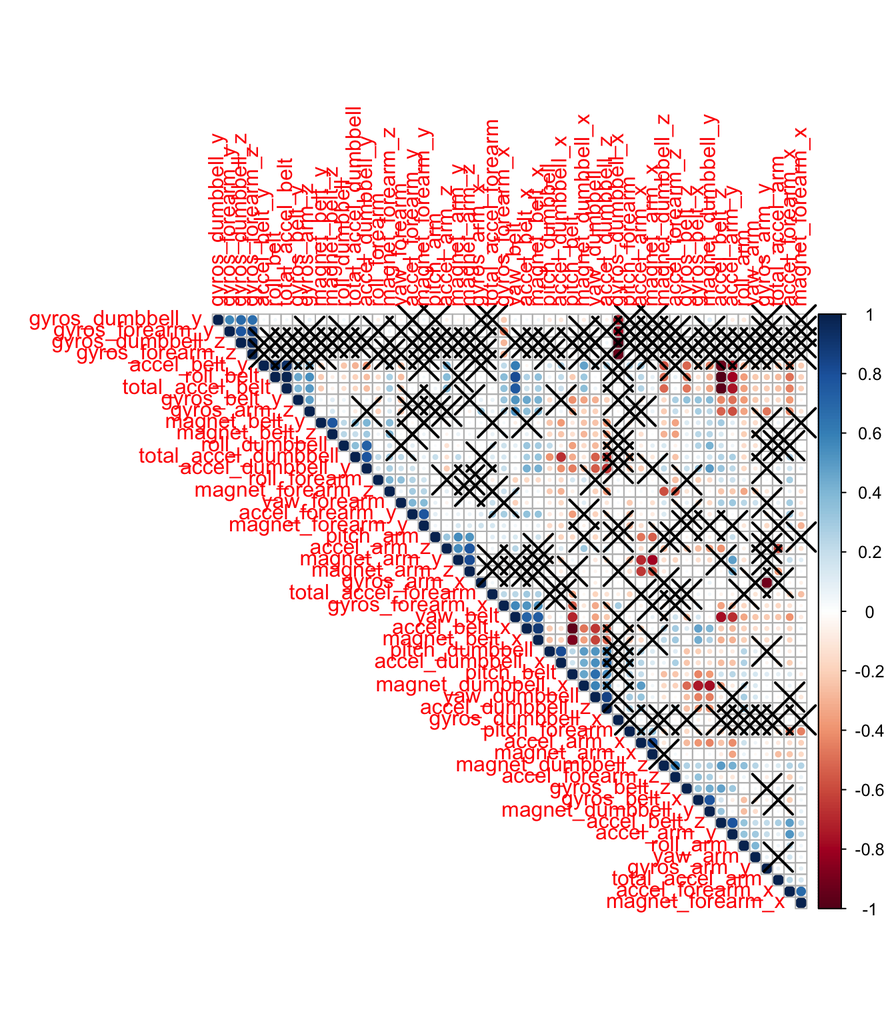

```r
# Specialized the insignificant value according to the significant level
corrplot(correlation, type = "upper", order = "hclust",
         p.mat = p.mat, sig.level = 0.05)
```

By looking at this figure, we decided to proceed with all the variables.

## Classification and Regression Tree

We will compare here three differents methods.

**The entire tree**

```r
set.seed(12345)
fitCART1 <- rpart(classe ~., data = trainData)
preditCART1 <- predict(fitCART1, newdata = testData, type = "class")
results1 <- confusionMatrix(preditCART1, testData$classe)
results1
```

```
## Confusion Matrix and Statistics
##
##           Reference
## Prediction    A    B    C    D    E
##          A 1498  196   69  106   25
##          B   42  669   85   86   92
##          C   43  136  739  129  131
##          D   33   85   98  553   44
##          E   58   53   35   90  790
##
## Overall Statistics
##
##                Accuracy : 0.722
##                  95% CI : (0.7104, 0.7334)
##     No Information Rate : 0.2845
##     P-Value [Acc > NIR] : < 0.00000000000000022
##
##                   Kappa : 0.6467
##  Mcnemar's Test P-Value : < 0.00000000000000022
##
## Statistics by Class:
##
##                      Class: A Class: B Class: C Class: D Class: E
## Sensitivity            0.8949   0.5874   0.7203  0.57365   0.7301
## Specificity            0.9060   0.9357   0.9097  0.94717   0.9509
## Pos Pred Value         0.7909   0.6869   0.6273  0.68020   0.7700
## Neg Pred Value         0.9559   0.9043   0.9390  0.91897   0.9399
## Prevalence             0.2845   0.1935   0.1743  0.16381   0.1839
## Detection Rate         0.2545   0.1137   0.1256  0.09397   0.1342
## Detection Prevalence   0.3218   0.1655   0.2002  0.13815   0.1743
## Balanced Accuracy      0.9004   0.7615   0.8150  0.76041   0.8405
```

We see a accuracy rate of 0.722.

This full tree including all predictor appears to be very complex and seems to be difficult to interpret because we have multiple predictors.

A other problem is that the full free can overfit the training data.

So let’s prunning the tree.

**Pruning the tree**

```r
fitCART2 <- train(classe ~ ., data = trainData, method = "rpart",
                trControl = trainControl(method = "cv", number = 10))
bestTune2 <- as.data.frame(fitCART2$bestTune)
print(bestTune2)
```

```
##           cp
## 1 0.03753433
```

```r
preditCART2 <- predict(fitCART2, newdata = testData)
results2 <- confusionMatrix(preditCART2, testData$classe)
results2
```

```
## Confusion Matrix and Statistics
##
##           Reference
## Prediction    A    B    C    D    E
##          A 1494  470  467  438  141
##          B   21  380   29  184  147
##          C  128  289  530  342  277
##          D    0    0    0    0    0
##          E   31    0    0    0  517
##
## Overall Statistics
##
##                Accuracy : 0.4963
##                  95% CI : (0.4835, 0.5092)
##     No Information Rate : 0.2845
##     P-Value [Acc > NIR] : < 0.00000000000000022
##
##                   Kappa : 0.3425
##  Mcnemar's Test P-Value : NA
##
## Statistics by Class:
##
##                      Class: A Class: B Class: C Class: D Class: E
## Sensitivity            0.8925  0.33363  0.51657   0.0000  0.47782
## Specificity            0.6400  0.91972  0.78679   1.0000  0.99355
## Pos Pred Value         0.4963  0.49934  0.33844      NaN  0.94343
## Neg Pred Value         0.9374  0.85187  0.88516   0.8362  0.89414
## Prevalence             0.2845  0.19354  0.17434   0.1638  0.18386
## Detection Rate         0.2539  0.06457  0.09006   0.0000  0.08785
## Detection Prevalence   0.5115  0.12931  0.26610   0.0000  0.09312
## Balanced Accuracy      0.7662  0.62667  0.65168   0.5000  0.73568
```

The best value for the complexity parameter is 0.0375 but the accuracy is 49.6%. The prediction accuracy of the full tree is better compared to the prune tree.

## Conditionnal inference tree

```r
fitCIT <- train(
  classe ~., data = trainData, method = "ctree2",
  trControl = trainControl("cv", number = 10),
  tuneGrid = expand.grid(maxdepth = 3, mincriterion = 0.95 )
  )
```

```r
preditCIT <- predict(fitCIT, newdata = testData)
results3 <- confusionMatrix(preditCIT, testData$classe)
results3
```

```
## Confusion Matrix and Statistics
##
##           Reference
## Prediction    A    B    C    D    E
##          A 1582 1036  757  861  678
##          B    0    0    0    0    0
##          C   92  100  269   18   62
##          D    0    3    0   79   20
##          E    0    0    0    6  322
##
## Overall Statistics
##
##                Accuracy : 0.3827
##                  95% CI : (0.3702, 0.3952)
##     No Information Rate : 0.2845
##     P-Value [Acc > NIR] : < 0.00000000000000022
##
##                   Kappa : 0.1582
##  Mcnemar's Test P-Value : NA
##
## Statistics by Class:
##
##                      Class: A Class: B Class: C Class: D Class: E
## Sensitivity            0.9450   0.0000  0.26218  0.08195  0.29760
## Specificity            0.2087   1.0000  0.94402  0.99533  0.99875
## Pos Pred Value         0.3219      NaN  0.49723  0.77451  0.98171
## Neg Pred Value         0.9053   0.8065  0.85835  0.84697  0.86324
## Prevalence             0.2845   0.1935  0.17434  0.16381  0.18386
## Detection Rate         0.2688   0.0000  0.04571  0.01342  0.05472
## Detection Prevalence   0.8350   0.0000  0.09193  0.01733  0.05573
## Balanced Accuracy      0.5769   0.5000  0.60310  0.53864  0.64817
```

The accuracy rate is 38.3%. This method is even worst than the previous two models.

## Random Forests

We will use 5 folds. Here we will display results and draw several graphics.

```r
cluster <- makeCluster(detectCores() - 1) # convention to leave 1 core for OS
registerDoParallel(cluster)
system.time(fitRF <-  train(
  classe ~., data = trainData, method = "rf",
  trControl = trainControl("cv", number = 5, allowParallel = TRUE),
  importance = TRUE
  ))
```

```
##    user  system elapsed
##  84.088   0.307 403.900
```

```r
stopCluster(cluster)
registerDoSEQ()
```

```r
bestTuneRF <- as.data.frame(fitRF$bestTuneRF)
print(bestTuneRF)
```

```
## data frame with 0 columns and 0 rows
```

```r
# Final model
print(fitRF$finalModel)
```

```
##
## Call:
##  randomForest(x = x, y = y, mtry = param$mtry, importance = TRUE)
##                Type of random forest: classification
##                      Number of trees: 500
## No. of variables tried at each split: 2
##
##         OOB estimate of  error rate: 0.67%
## Confusion matrix:
##      A    B    C    D    E class.error
## A 3901    2    2    0    1 0.001280082
## B   15 2635    8    0    0 0.008653123
## C    0   20 2374    2    0 0.009181970
## D    0    0   34 2216    2 0.015985790
## E    0    0    0    6 2519 0.002376238
```

```r
print(fitRF)
```

```
## Random Forest
##
## 13737 samples
##    52 predictor
##     5 classes: 'A', 'B', 'C', 'D', 'E'
##
## No pre-processing
## Resampling: Cross-Validated (5 fold)
## Summary of sample sizes: 10989, 10989, 10990, 10990, 10990
## Resampling results across tuning parameters:
##
##   mtry  Accuracy   Kappa
##    2    0.9918468  0.9896852
##   27    0.9900996  0.9874752
##   52    0.9847854  0.9807497
##
## Accuracy was used to select the optimal model using the largest value.
## The final value used for the model was mtry = 2.
```

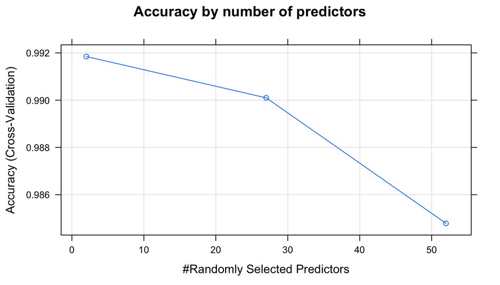

```r
plot(fitRF, main = "Accuracy by number of predictors")
```

```r
predictRF <- predict(fitRF, newdata = testData)
results4 <- confusionMatrix(predictRF, testData$classe)
results4
```

```
## Confusion Matrix and Statistics
##
##           Reference
## Prediction    A    B    C    D    E
##          A 1673   11    0    0    0
##          B    1 1123   14    0    0
##          C    0    5 1009   24    0
##          D    0    0    3  940    3
##          E    0    0    0    0 1079
##
## Overall Statistics
##
##                Accuracy : 0.9896
##                  95% CI : (0.9867, 0.9921)
##     No Information Rate : 0.2845
##     P-Value [Acc > NIR] : < 0.00000000000000022
##
##                   Kappa : 0.9869
##  Mcnemar's Test P-Value : NA
##
## Statistics by Class:
##
##                      Class: A Class: B Class: C Class: D Class: E
## Sensitivity            0.9994   0.9860   0.9834   0.9751   0.9972
## Specificity            0.9974   0.9968   0.9940   0.9988   1.0000
## Pos Pred Value         0.9935   0.9868   0.9721   0.9937   1.0000
## Neg Pred Value         0.9998   0.9966   0.9965   0.9951   0.9994
## Prevalence             0.2845   0.1935   0.1743   0.1638   0.1839
## Detection Rate         0.2843   0.1908   0.1715   0.1597   0.1833
## Detection Prevalence   0.2862   0.1934   0.1764   0.1607   0.1833
## Balanced Accuracy      0.9984   0.9914   0.9887   0.9869   0.9986
```

The accuracy rate is 99%.

The Out Of Bag error is used to measure the performance of aggregation models. This is the average error calculated each time on the samples that were not used to calculate the model. Our Out of Bag is 0.67%.

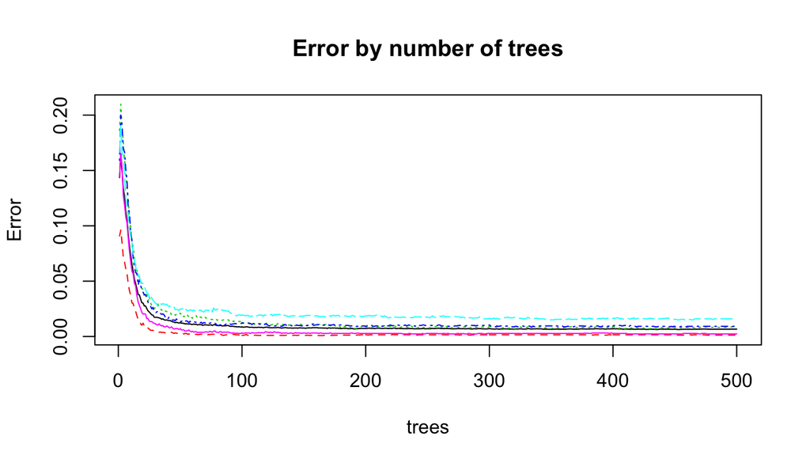

```r
plot(fitRF$finalModel, main = "Error by number of trees")
```

Let’s look at the importance order of the variables:

```r
MostImpVars <- varImp(fitRF)
MostImpVars
```

```
## rf variable importance
##
##   variables are sorted by maximum importance across the classes
##   only 20 most important variables shown (out of 52)
##
##                       A      B     C     D     E
## pitch_belt        69.40 100.00 68.67 66.32 59.66
## yaw_belt          84.76  90.89 77.35 99.64 68.01
## roll_belt         57.27  83.40 94.40 79.45 49.55
## roll_arm          38.25  81.20 64.01 55.69 45.45
## magnet_dumbbell_z 71.93  59.24 67.48 54.85 49.63
## magnet_dumbbell_y 47.92  49.06 69.68 49.79 37.28
## gyros_forearm_y   28.84  63.19 59.13 54.34 34.30
## pitch_forearm     43.70  62.18 55.31 50.08 46.69
## magnet_dumbbell_x 35.49  43.00 61.74 38.66 32.89
## yaw_arm           34.57  58.31 42.98 55.94 38.65
## accel_dumbbell_y  38.70  52.79 48.72 57.85 49.51
## gyros_dumbbell_x  29.19  55.41 44.72 35.42 24.45
## gyros_arm_y       23.47  54.53 29.71 42.04 34.44
## magnet_belt_z     45.34  47.60 50.25 53.94 42.16
## roll_dumbbell     30.35  35.56 53.43 41.09 32.92
## accel_belt_z      33.83  51.11 52.54 41.10 33.49
## accel_dumbbell_z  41.60  50.86 52.41 44.10 48.18
## gyros_dumbbell_y  30.93  47.54 51.73 38.67 34.55
## accel_forearm_z   37.13  48.10 49.37 29.22 42.87
## magnet_forearm_y  33.26  42.41 48.86 41.32 42.48
```

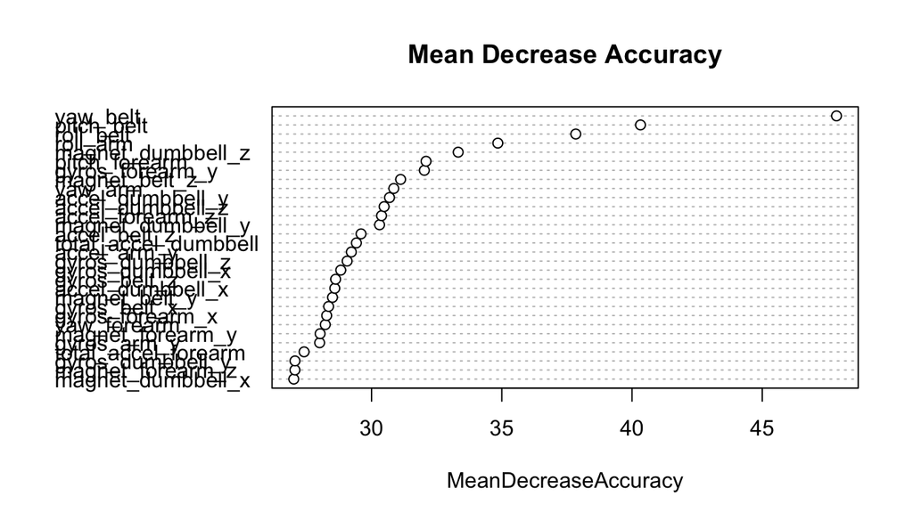

```r
# Plot MeanDecreaseAccuracy
varImpPlot(fitRF$finalModel, type = 1, main = "Mean Decrease Accuracy")
```

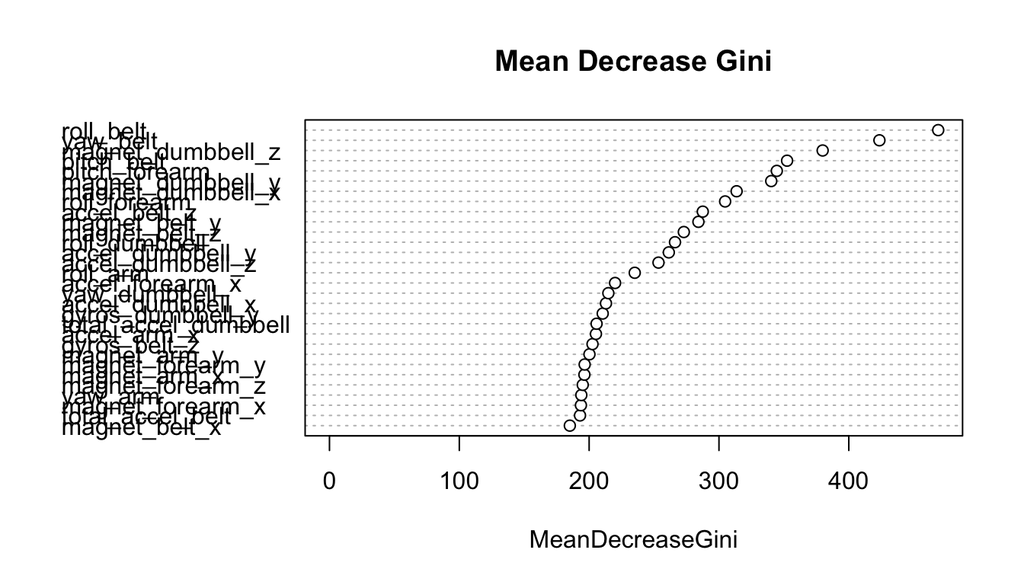

```r
# Plot MeanDecreaseGini
varImpPlot(fitRF$finalModel, type = 2, main = "Mean Decrease Gini")
```

MeanDecreaseAccuracy is the average decrease of model accuracy in predicting the outcome of the out-of-bag samples when a specific variable is excluded from the model.

MeanDecreaseGini is the average decrease in node impurity that results from splits over that variable.

## Generalized Boost Regression

```r
system.time(fitGBR <- train(classe~., data = trainData, method = "gbm",  trControl = trainControl("cv", number = 5), verbose = FALSE))
```

```
##    user  system elapsed
## 221.091   1.097 222.559
```

```r
fitGBR
```

```
## Stochastic Gradient Boosting
##
## 13737 samples
##    52 predictor
##     5 classes: 'A', 'B', 'C', 'D', 'E'
##
## No pre-processing
## Resampling: Cross-Validated (5 fold)
## Summary of sample sizes: 10988, 10991, 10990, 10991, 10988
## Resampling results across tuning parameters:
##
##   interaction.depth  n.trees  Accuracy   Kappa
##   1                   50      0.7543836  0.6885296
##   1                  100      0.8249243  0.7784040
##   1                  150      0.8572456  0.8193255
##   2                   50      0.8577563  0.8197246
##   2                  100      0.9059465  0.8809407
##   2                  150      0.9332456  0.9155220
##   3                   50      0.8964114  0.8688239
##   3                  100      0.9438019  0.9288763
##   3                  150      0.9617834  0.9516464
##
## Tuning parameter 'shrinkage' was held constant at a value of 0.1
##
## Tuning parameter 'n.minobsinnode' was held constant at a value of 10
## Accuracy was used to select the optimal model using the largest value.
## The final values used for the model were n.trees = 150,
##  interaction.depth = 3, shrinkage = 0.1 and n.minobsinnode = 10.
```

```r
predictGBR <- predict(fitGBR, testData)
results5 <- confusionMatrix(predictGBR, testData$classe)
results5
```

```
## Confusion Matrix and Statistics
##
##           Reference
## Prediction    A    B    C    D    E
##          A 1645   34    0    2    2
##          B   21 1064   38    0   23
##          C    5   39  969   38    6
##          D    3    2   17  918   22
##          E    0    0    2    6 1029
##
## Overall Statistics
##
##                Accuracy : 0.9558
##                  95% CI : (0.9503, 0.9609)
##     No Information Rate : 0.2845
##     P-Value [Acc > NIR] : < 0.00000000000000022
##
##                   Kappa : 0.9441
##  Mcnemar's Test P-Value : 0.00000004006
##
## Statistics by Class:
##
##                      Class: A Class: B Class: C Class: D Class: E
## Sensitivity            0.9827   0.9342   0.9444   0.9523   0.9510
## Specificity            0.9910   0.9827   0.9819   0.9911   0.9983
## Pos Pred Value         0.9774   0.9284   0.9167   0.9543   0.9923
## Neg Pred Value         0.9931   0.9842   0.9882   0.9907   0.9891
## Prevalence             0.2845   0.1935   0.1743   0.1638   0.1839
## Detection Rate         0.2795   0.1808   0.1647   0.1560   0.1749
## Detection Prevalence   0.2860   0.1947   0.1796   0.1635   0.1762
## Balanced Accuracy      0.9868   0.9584   0.9632   0.9717   0.9747
```

The accuracy rate is 95.6%. This model perform well.

## CONCLUSION

From the above, we can see that randomForest is the better performing algorithm with 0.67% out-of-bag (OOB) error rate and the model achieved an accuracy of 99%.

The Random Forest model will be applied to predict the 20 quiz testing dataset.